# Modelação

Victor Abreu

2022-12-12

# Introdução

Primeiro, comecemos por verificar se estamos a iniciar o nosso trabalho no diretório correcto:

```r
getwd()
```

```
## [1] "C:/Users/victo/Documents/Data & Analytics/Portfolio/analytics_reprex"
```

Este aspeto é crucial, até para garantir a correta reproducibilidade deste nosso projeto.

Importemos ainda as bibliotecas necessárias (não sem antes verificar se as mesmas estão instaladas), bem como o nosso *script* orientado para a **modelação** estatística:

```r
# Nomes dos packages

packages <- c("class", "nnet", "rpart", "rpart.plot", "e1071")

# Instalação de packages (apenas se necessário!)

installed_packages <- packages %in% rownames(installed.packages())

if (any(installed_packages == FALSE)) {

    install.packages(packages[!installed_packages])

}

# Carregamento de packages

invisible(lapply(packages, library, character.only = TRUE))
```

```r
source("./misc/scripts/mod.R", encoding = 'UTF-8')
```

# Importação de dados

Efetuemos a importação dos dados exportados no pré-processamento, através do comando `read.csv`, com posterior confirmação (e ajustando a natureza dos dados em cada coluna):

```r
iris.treino <- read.csv2("./pipeline/3_modelos/iris_treino.csv", sep = ",")
iris.val <- read.csv2("./pipeline/3_modelos/iris_val.csv", sep = ",")
iris.teste <- read.csv2("./pipeline/3_modelos/iris_teste.csv", sep = ",")
```

```r
iris.treino$sepal.length <- as.numeric(iris.treino$sepal.length)
iris.treino$sepal.width <- as.numeric(iris.treino$sepal.width)
iris.treino$petal.length <- as.numeric(iris.treino$petal.length)
iris.treino$petal.width <- as.numeric(iris.treino$petal.width)

iris.treino$sepal.length.norm <- as.numeric(iris.treino$sepal.length.norm)
iris.treino$sepal.width.norm <- as.numeric(iris.treino$sepal.width.norm)
iris.treino$petal.length.norm <- as.numeric(iris.treino$petal.length.norm)
iris.treino$petal.width.norm <- as.numeric(iris.treino$petal.width.norm)
```

```r
iris.val$sepal.length <- as.numeric(iris.val$sepal.length)
iris.val$sepal.width <- as.numeric(iris.val$sepal.width)
iris.val$petal.length <- as.numeric(iris.val$petal.length)
iris.val$petal.width <- as.numeric(iris.val$petal.width)

iris.val$sepal.length.norm <- as.numeric(iris.val$sepal.length.norm)
iris.val$sepal.width.norm <- as.numeric(iris.val$sepal.width.norm)
iris.val$petal.length.norm <- as.numeric(iris.val$petal.length.norm)
iris.val$petal.width.norm <- as.numeric(iris.val$petal.width.norm)
```

```r
iris.teste$sepal.length <- as.numeric(iris.teste$sepal.length)
iris.teste$sepal.width <- as.numeric(iris.teste$sepal.width)
iris.teste$petal.length <- as.numeric(iris.teste$petal.length)
iris.teste$petal.width <- as.numeric(iris.teste$petal.width)

iris.teste$sepal.length.norm <- as.numeric(iris.teste$sepal.length.norm)
iris.teste$sepal.width.norm <- as.numeric(iris.teste$sepal.width.norm)
iris.teste$petal.length.norm <- as.numeric(iris.teste$petal.length.norm)
iris.teste$petal.width.norm <- as.numeric(iris.teste$petal.width.norm)
```

# Ajustamento de modelos no conjunto de treino

Nesta fase, iremos construir modelos que nos permitam prever a espécie das flores com base nas medições já consideradas - largura das sépalas e comprimento das pétalas.

Este será, portanto, um problema de classificação com várias categorias (*multiclass classification*) e, nesse sentido, iremos admitir a existência de cinco tipos de modelos, a saber:

1. **Regressão logística** (enquanto caso particular de rede neural, numa variante simples - dados os resultados que veremos de seguida, não se justifica o recurso a redes mais complexas);
2. $k$-**vizinhos mais próximos**;
3. **Árvores de decisão**;
4. *Naive Bayes*;
5. **Máquinas de vetores de suporte**.

Seguindo a ordem especificada, comecemos pela regressão logística, apresentando após o ajustamento do modelo a matriz de confusão que lhe está associada:

```r
obs <- iris.treino$class
pred <- predict(reg.log, iris.treino)

conf.mat <- table(obs, pred)
conf.mat
```

```
##             pred
## obs          setosa versicolor virginica
##   setosa         17          0         0
##   versicolor      0         14         1
##   virginica       0          1        15
```

Os resultados obtidos, ainda que apenas num ambiente de treino (para já), são bastante encorajadores. Contudo, como este problema de classificação não possui natureza binária, o cálculo de métricas como a *accuracy*, a *precision* e a *recall* não é tão imediato. Por isso, serão calculadas de seguida estes valores para cada classe/espécie, apenas para este modelo (sem perda de generalidade, no entanto):

```r
obs.setosa <- ifelse(iris.treino$class == "setosa", "setosa", "other")
pred.setosa <- ifelse(predict(reg.log, iris.treino) == "setosa", "setosa", "other")

conf.mat.setosa <- table(obs.setosa, pred.setosa)
accuracy.setosa <- sum(diag(conf.mat.setosa))/sum(conf.mat.setosa)
precision.setosa <- sum(pred.setosa == "setosa" & obs.setosa == "setosa")/sum(pred.setosa == "setosa") # das que previ, quantas acertei?
recall.setosa <- sum(pred.setosa == "setosa" & obs.setosa == "setosa")/sum(obs.setosa == "setosa") # das que eram certas, quantas previ?
```

```r
obs.versicolor <- ifelse(iris.treino$class == "versicolor", "versicolor", "other")
pred.versicolor <- ifelse(predict(reg.log, iris.treino) == "versicolor", "versicolor", "other")

conf.mat.versicolor <- table(obs.versicolor, pred.versicolor)
accuracy.versicolor <- sum(diag(conf.mat.versicolor))/sum(conf.mat.versicolor)
precision.versicolor <- sum(pred.versicolor == "versicolor" & obs.versicolor == "versicolor")/sum(pred.versicolor == "versicolor") # das que previ, quantas acertei?
recall.versicolor <- sum(pred.versicolor == "versicolor" & obs.versicolor == "versicolor")/sum(obs.versicolor == "versicolor") # das que eram certas, quantas previ?
```

```r
obs.virginica <- ifelse(iris.treino$class == "virginica", "virginica", "other")
pred.virginica <- ifelse(predict(reg.log, iris.treino) == "virginica", "virginica", "other")

conf.mat.virginica <- table(obs.virginica, pred.virginica)
accuracy.virginica <- sum(diag(conf.mat.virginica))/sum(conf.mat.virginica)
precision.virginica <- sum(pred.virginica == "virginica" & obs.virginica == "virginica")/sum(pred.virginica == "virginica") # das que previ, quantas acertei?
recall.virginica <- sum(pred.virginica == "virginica" & obs.virginica == "virginica")/sum(obs.virginica == "virginica") # das que eram certas, quantas previ?
```

```r
result <- data.frame(accuracy = c(accuracy.setosa, accuracy.versicolor, accuracy.virginica), precision = c(precision.setosa, precision.versicolor, precision.virginica), recall = c(recall.setosa, recall.versicolor, recall.virginica), row.names = c("setosa", "versicolor", "virginica"))
result
```

```
##             accuracy precision    recall
## setosa     1.0000000 1.0000000 1.0000000
## versicolor 0.9583333 0.9333333 0.9333333
## virginica  0.9583333 0.9375000 0.9375000
```

De seguida, ajustemos um modelo de $k$-vizinhos mais próximos, com $k = 3$, e avaliemos o seu desempenho: (…)

```r
obs <- iris.treino$class
pred <- knn(iris.treino[, c("sepal.width", "petal.length")], iris.treino[, c("sepal.width", "petal.length")], as.factor(iris.treino$class), k = 3)

table(obs, pred)
```

```
##             pred
## obs          setosa versicolor virginica
##   setosa         17          0         0
##   versicolor      0         14         1
##   virginica       0          1        15
```

Poderíamos ter efetuado uma otimização no hiperparâmetro $k$, se assim o desejássemos, mas os resultados parecem ser já bastante interessantes.

Passemos às árvores de decisão:

```r
arv.dec <- rpart(class ~ sepal.width + petal.length, data = iris.treino)
print(arv.dec)
```

```
## n= 48
##
## node), split, n, loss, yval, (yprob)
##       * denotes terminal node
##
## 1) root 48 31 setosa (0.35416667 0.31250000 0.33333333)
##   2) petal.length< 2.65 17  0 setosa (1.00000000 0.00000000 0.00000000) *
##   3) petal.length>=2.65 31 15 virginica (0.00000000 0.48387097 0.51612903)
##     6) petal.length< 4.75 15  1 versicolor (0.00000000 0.93333333 0.06666667) *
##     7) petal.length>=4.75 16  1 virginica (0.00000000 0.06250000 0.93750000) *
```

```r
obs <- iris.treino$class
pred <- predict(arv.dec, iris.treino, type = "class")

table(obs, pred)
```

```
##             pred
## obs          setosa versicolor virginica
##   setosa         17          0         0
##   versicolor      0         14         1
##   virginica       0          1        15
```

Mais uma vez, resultados promissores. E no modelo *naive Bayes*?

```r
mod.nb <- naiveBayes(class ~ sepal.width + petal.length, data = iris.treino)
```

```r
obs <- iris.treino$class
pred <- predict(mod.nb, iris.treino)

table(obs, pred)
```

```
##             pred
## obs          setosa versicolor virginica
##   setosa         17          0         0
##   versicolor      0         14         1
##   virginica       0          2        14
```

Também! Por último, recorrendo às *support vector machines*,

```r
mod.svm <- svm(iris.treino[, 2:3], as.factor(iris.treino$class))
```

```r
obs <- iris.treino$class
pred <- predict(mod.svm, iris.treino[, 2:3], probability = FALSE)

table(obs, pred)
```

```
##             pred
## obs          setosa versicolor virginica
##   setosa         17          0         0
##   versicolor      0         14         1
##   virginica       0          1        15
```

# Comparação de modelos no conjunto de validação

Ajustados estes modelos, comparemos os seus desempenhos no conjunto de validação, para depois escolher o melhor modelo, o qual será colocado à prova no conjunto de teste.

Para a **regressão logística**, teremos:

```r
obs <- iris.val$class
pred <- predict(reg.log, iris.val)

table(obs, pred)
```

```
##             pred
## obs          setosa versicolor virginica
##   setosa          5          0         0
##   versicolor      0          6         1
##   virginica       0          0         9
```

Para os $k$-**vizinhos mais próximos**, teremos:

```r
obs <- iris.val$class
pred <- knn(iris.treino[, c("sepal.width", "petal.length")], iris.val[, c("sepal.width", "petal.length")], as.factor(iris.treino$class), k = 3)

table(obs, pred)
```

```
##             pred
## obs          setosa versicolor virginica
##   setosa          5          0         0
##   versicolor      0          5         2
##   virginica       0          0         9
```

Para a **árvore de decisão**, teremos:

```r
obs <- iris.val$class
pred <- predict(arv.dec, iris.val, type = "class")

table(obs, pred)
```

```
##             pred
## obs          setosa versicolor virginica
##   setosa          5          0         0
##   versicolor      0          6         1
##   virginica       0          0         9
```

Para o modelo **naive Bayes**, teremos:

```r
obs <- iris.val$class
pred <- predict(mod.nb, iris.val)

table(obs, pred)
```

```
##             pred
## obs          setosa versicolor virginica
##   setosa          5          0         0
##   versicolor      0          6         1
##   virginica       0          0         9
```

Para as **máquinas vetoriais de suporte**, teremos:

```r
obs <- iris.val$class
pred <- predict(mod.svm, iris.val[, 2:3], probability = FALSE)

table(obs, pred)
```

```
##             pred
## obs          setosa versicolor virginica
##   setosa          5          0         0
##   versicolor      0          6         1
##   virginica       0          1         8
```

Por curiosidade, todos os modelos parecem ser quase perfeitos, à exceção de uma ou duas previsões menos certas. A principal culpada é a observação número `12`:

```r
which(iris.val$class != predict(reg.log, iris.val))
```

```
## [1] 12
```

```r
which(iris.val$class != knn(iris.treino[, c("sepal.width", "petal.length")], iris.val[, c("sepal.width", "petal.length")], as.factor(iris.treino$class), k = 3))
```

```
## [1] 12 19
```

```r
which(iris.val$class != predict(arv.dec, iris.val, type = "class"))
```

```
## [1] 12
```

```r
which(iris.val$class != predict(mod.nb, iris.val))
```

```
## [1] 12
```

```r
which(iris.val$class != predict(mod.svm, iris.val[, 2:3], probability = FALSE))
```

```
## [1]  9 12
```

mas qual é esta observação?

```r
iris.val[12, c("sepal.width", "petal.length", "class")]
```

```
##    sepal.width petal.length      class
## 12           3            5 versicolor
```

# Avaliação final, no conjunto de teste

Construída a árvore de decisão, avaliemos a sua performance no conjunto de teste, o qual visa simular da forma mais fiel possível *previously unseen data*:

```r
obs <- iris.teste$class
pred <- predict(arv.dec, iris.teste, type = "class")

table(obs, pred)
```

```
##             pred
## obs          setosa versicolor virginica
##   setosa          6          0         0
##   versicolor      0          3         0
##   virginica       0          0         8
```

O resultado não poderia ser melhor (neste subconjunto)!

# Interpretação do modelo escolhido

Mais uma vez, teremos:

```r
print(arv.dec)
```

```
## n= 48
##
## node), split, n, loss, yval, (yprob)
##       * denotes terminal node
##
## 1) root 48 31 setosa (0.35416667 0.31250000 0.33333333)
##   2) petal.length< 2.65 17  0 setosa (1.00000000 0.00000000 0.00000000) *
##   3) petal.length>=2.65 31 15 virginica (0.00000000 0.48387097 0.51612903)
##     6) petal.length< 4.75 15  1 versicolor (0.00000000 0.93333333 0.06666667) *
##     7) petal.length>=4.75 16  1 virginica (0.00000000 0.06250000 0.93750000) *
```

Este modelo é ainda mais simples do que pensávamos! Basicamente, este utiliza apenas uma *feature* e diz-nos o seguinte:

1. Se o comprimento das pétalas for inferior a $2.65$ $cm$, estaremos perante uma flor da espécie `setosa`;
2. Se o comprimento das pétalas pertencer ao intervalo $[2.65 cm, 4.75 cm[$, estaremos perante uma flor da espécie `versicolor`;
3. Se o comprimento das pétalas igualar ou exceder $4.75$ $cm$, estaremos perante uma flor da espécie `virginica`.

No entanto, esta pode não ser a visualização mais apelativa. Nesse sentido, executemos:

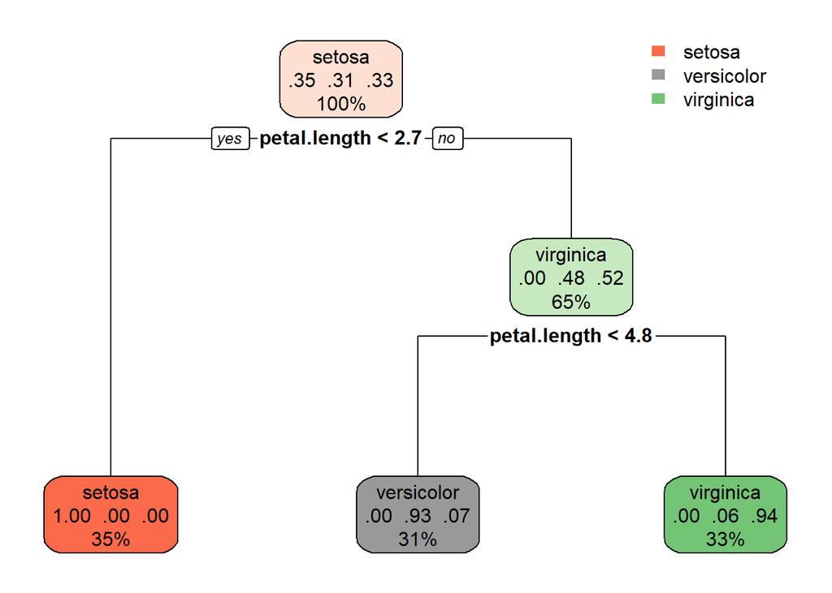

```r
rpart.plot(arv.dec)
```

Por último, visualizemos as previsões geradas pelo modelo no conjunto de teste (as quais, ao serem totalmente precisas, refletem também as classes reais):

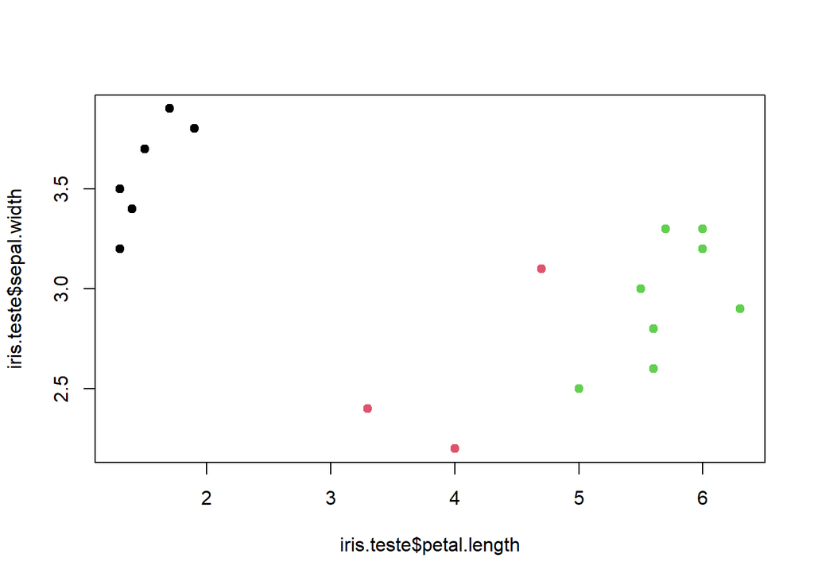

```r
plot(iris.teste$petal.length, iris.teste$sepal.width, col = predict(arv.dec, iris.teste, type = "class"), pch = 19)
```